# Final Project

```
##
## Call:
## lm(formula = happiness_score ~ gdp_per_capita + health + freedom +
##     family + generosity + government_trust, data = WHC_2016)
##
## Residuals:
##      Min       1Q   Median       3Q      Max
## -1.42643 -0.30534 -0.01359  0.31677  1.42252
##
## Coefficients:
##                  Estimate Std. Error t value Pr(>|t|)
## (Intercept)        1.7673     0.2169   8.147 3.88e-13 ***
## gdp_per_capita     0.8703     0.2576   3.379 0.000981 ***
## health             1.5105     0.3982   3.793 0.000234 ***
## freedom            0.9761     0.4743   2.058 0.041745 *
## family             1.1695     0.2611   4.480 1.71e-05 ***
## generosity         0.7810     0.4262   1.833 0.069303 .
## government_trust   1.0751     0.4986   2.156 0.033067 *
## ---
## Signif. codes:  0 '***' 0.001 '**' 0.01 '*' 0.05 '.' 0.1 ' ' 1
##
## Residual standard error: 0.5444 on 121 degrees of freedom
##   (4 observations deleted due to missingness)
## Multiple R-squared:  0.7945, Adjusted R-squared:  0.7843
## F-statistic: 77.97 on 6 and 121 DF,  p-value: < 2.2e-16
```

```
##
## Call:
## lm(formula = happiness_score ~ gdp_per_capita + health + freedom +
##     generosity + government_trust + cpi_score, data = WHC_2017)
##
## Residuals:
##      Min       1Q   Median       3Q      Max
## -1.93893 -0.34155  0.05238  0.31919  1.03359
##
## Coefficients:
##                  Estimate Std. Error t value Pr(>|t|)
## (Intercept)       2.27209    0.23217   9.786  < 2e-16 ***
## gdp_per_capita    1.11972    0.27330   4.097 7.57e-05 ***
## health            1.40076    0.46821   2.992  0.00336 **
## freedom           1.52726    0.47356   3.225  0.00162 **
## generosity        0.75442    0.58609   1.287  0.20046
## government_trust  0.02917    0.73394   0.040  0.96836
## cpi_score         0.08507    0.04808   1.769  0.07936 .
## ---
## Signif. codes:  0 '***' 0.001 '**' 0.01 '*' 0.05 '.' 0.1 ' ' 1
##
## Residual standard error: 0.5776 on 122 degrees of freedom
## Multiple R-squared:  0.7342, Adjusted R-squared:  0.7212
## F-statistic: 56.17 on 6 and 122 DF,  p-value: < 2.2e-16
```

```
## Start:  AIC=-134.81
## happiness_score ~ gdp_per_capita + health + freedom + generosity +
##     government_trust + cpi_score
##
##                    Df Sum of Sq    RSS     AIC
## - government_trust  1    0.0005 40.702 -136.81
## - generosity        1    0.5528 41.255 -135.07
## <none>                          40.702 -134.81
## - cpi_score         1    1.0443 41.746 -133.54
## - health            1    2.9861 43.688 -127.67
## - freedom           1    3.4701 44.172 -126.25
## - gdp_per_capita    1    5.5999 46.302 -120.18
##
## Step:  AIC=-136.81
## happiness_score ~ gdp_per_capita + health + freedom + generosity +
##     cpi_score
##
##                  Df Sum of Sq    RSS     AIC
## - generosity      1    0.5814 41.284 -136.97
## <none>                        40.702 -136.81
## - cpi_score       1    1.5274 42.230 -134.05
## - health          1    2.9858 43.688 -129.67
## - freedom         1    3.5793 44.282 -127.93
## - gdp_per_capita  1    5.6660 46.368 -121.99
##
## Step:  AIC=-136.98
## happiness_score ~ gdp_per_capita + health + freedom + cpi_score
##
##                  Df Sum of Sq    RSS     AIC
## <none>                        41.284 -136.97
## - cpi_score       1    1.9164 43.200 -133.12
## - health          1    2.7989 44.083 -130.51
## - freedom         1    5.1418 46.425 -123.83
## - gdp_per_capita  1    5.2875 46.571 -123.43
```

```
##
## Call:
## lm(formula = happiness_score ~ gdp_per_capita + health + freedom +
##     cpi_score, data = WHC_2017)
##
## Coefficients:
##    (Intercept)  gdp_per_capita          health         freedom       cpi_score
##        2.36908         1.07087         1.35156         1.73267         0.09508
```

```
##
## Call:
## lm(formula = happiness_score ~ gdp_per_capita + health + freedom +
##     cpi_score, data = WHC_2017)
##
## Residuals:
##      Min       1Q   Median       3Q      Max
## -2.09132 -0.32208  0.09886  0.33477  1.00877
##
## Coefficients:
##                Estimate Std. Error t value Pr(>|t|)
## (Intercept)     2.36908    0.21400  11.070  < 2e-16 ***
## gdp_per_capita  1.07087    0.26871   3.985 0.000114 ***
## health          1.35156    0.46614   2.899 0.004423 **
## freedom         1.73267    0.44090   3.930 0.000140 ***
## cpi_score       0.09508    0.03963   2.399 0.017920 *
## ---
## Signif. codes:  0 '***' 0.001 '**' 0.01 '*' 0.05 '.' 0.1 ' ' 1
##
## Residual standard error: 0.577 on 124 degrees of freedom
## Multiple R-squared:  0.7304, Adjusted R-squared:  0.7217
## F-statistic:    84 on 4 and 124 DF,  p-value: < 2.2e-16
```

The initial linear regression model came from a subset of our data set that only contains data for the year 2017. As with the previous initial models, the happiness score is the dependent variable, while the determinants of happiness and the CPI score are the independent variables. The model selection results display that the best combination of independent variables to influence the happiness score in 2017 include GDP per capita, health, freedom, and the CPI score . Based on these results, we constructed a linear regression model and used the outcomes of its model summary for analysis. The y-intercept of the new model for 2017 is 2.36908, and the independent variables with the highest coefficients were freedom, health, and GDP per capita– with freedom having the highest coefficient. Therefore, the independent variables that largely impacted happiness in 2017 were freedom, health, and GDP per capita. The adjusted R^2 value for this model is 0.7217, while the p-value of this model is < 2.2e-16, with alpha set at 0.05 and degrees of freedom at 124. This p-value suggests that we can reject the null hypothesis explaining that the relationship between the variables is 0 because there is evidence of a statistically significant relationship between the variables in this model.

```
##
## Call:
## lm(formula = happiness_score ~ gdp_per_capita + health + freedom +
##     generosity + government_trust + cpi_score, data = WHC_2018)
##
## Residuals:
##      Min       1Q   Median       3Q      Max
## -1.84668 -0.33267  0.06428  0.35831  1.01233
##
## Coefficients:
##                  Estimate Std. Error t value Pr(>|t|)
## (Intercept)       2.32274    0.19293  12.039  < 2e-16 ***
## gdp_per_capita    1.39569    0.25096   5.561 1.63e-07 ***
## health            1.28883    0.42374   3.042 0.002886 **
## freedom           1.46652    0.40174   3.650 0.000388 ***
## generosity        0.83046    0.54222   1.532 0.128232
## government_trust  0.12230    0.67572   0.181 0.856681
## cpi_score         0.04821    0.04452   1.083 0.281019
## ---
## Signif. codes:  0 '***' 0.001 '**' 0.01 '*' 0.05 '.' 0.1 ' ' 1
##
## Residual standard error: 0.5555 on 121 degrees of freedom
## Multiple R-squared:  0.7688, Adjusted R-squared:  0.7574
## F-statistic: 67.07 on 6 and 121 DF,  p-value: < 2.2e-16
```

```
## Start:  AIC=-143.72
## happiness_score ~ gdp_per_capita + health + freedom + generosity +
##     government_trust + cpi_score
##
##                    Df Sum of Sq    RSS     AIC
## - government_trust  1    0.0101 37.342 -145.68
## - cpi_score         1    0.3618 37.694 -144.49
## <none>                          37.332 -143.72
## - generosity        1    0.7237 38.056 -143.26
## - health            1    2.8542 40.186 -136.29
## - freedom           1    4.1113 41.443 -132.35
## - gdp_per_capita    1    9.5428 46.875 -116.58
##
## Step:  AIC=-145.68
## happiness_score ~ gdp_per_capita + health + freedom + generosity +
##     cpi_score
##
##                  Df Sum of Sq    RSS     AIC
## - cpi_score       1    0.5562 37.898 -145.79
## <none>                        37.342 -145.68
## - generosity      1    0.8110 38.153 -144.93
## - health          1    2.8523 40.194 -138.26
## - freedom         1    4.2748 41.617 -133.81
## - gdp_per_capita  1    9.5774 46.919 -118.46
##
## Step:  AIC=-145.79
## happiness_score ~ gdp_per_capita + health + freedom + generosity
##
##                  Df Sum of Sq    RSS     AIC
## <none>                        37.898 -145.79
## - generosity      1    1.0505 38.949 -144.29
## - health          1    3.6032 41.502 -136.17
## - freedom         1    5.2650 43.163 -131.14
## - gdp_per_capita  1   12.5957 50.494 -111.06
```

```
##
## Call:
## lm(formula = happiness_score ~ gdp_per_capita + health + freedom +
##     generosity, data = WHC_2018)
##
## Coefficients:
##    (Intercept)  gdp_per_capita          health         freedom      generosity
##         2.2892          1.5100          1.4040          1.5978          0.9606
```

[output not shown]

The initial linear regression model came from a subset of our data set that only contains data for the year 2018. As with the previous initial models, the happiness score is the dependent variable, while the determinants of happiness and the CPI score are the independent variables. The model selection results display that the best combination of independent variables to influence the happiness score in 2018 include GDP per capita, health, freedom, and generosity. Based on these results, we constructed a linear regression model and used the outcomes of its model summary for analysis. The y-intercept of the new model for 2018 is 2.2892, and the independent variables with the highest coefficients were freedom, GDP per capita, and health– with freedom having the highest coefficient. Therefore, the independent variables that largely impacted happiness in 2018 were freedom, GDP per capita, and health. The adjusted R^2 value for this model is 0.7577, while the p-value is < 2.2e-16, with alpha set at 0.05 and degrees of freedom at 123. This p-value suggests that we can reject the null hypothesis explaining that the relationship between the variables is 0 because there is evidence of a statistically significant relationship between the variables in this model.

```
##
## Call:
## lm(formula = happiness_score ~ gdp_per_capita + health + freedom +
##     family + generosity + government_trust + cpi_score, data = WHC_2019)
##
## Residuals:
##      Min       1Q   Median       3Q      Max
## -1.37049 -0.26677 -0.01843  0.32268  1.05837
##
## Coefficients:
##                  Estimate Std. Error t value Pr(>|t|)
## (Intercept)       2.09855    0.17575  11.941  < 2e-16 ***
## gdp_per_capita    0.94511    0.25598   3.692 0.000336 ***
## health            1.89926    0.42335   4.486 1.67e-05 ***
## freedom           1.05511    0.47389   2.226 0.027848 *
## family            1.01990    0.25708   3.967 0.000124 ***
## generosity        0.56639    0.38360   1.477 0.142420
## government_trust  1.40819    0.55506   2.537 0.012464 *
## cpi_score        -0.04989    0.04180  -1.194 0.234963
## ---
## Signif. codes:  0 '***' 0.001 '**' 0.01 '*' 0.05 '.' 0.1 ' ' 1
##
## Residual standard error: 0.5174 on 120 degrees of freedom
##   (4 observations deleted due to missingness)
## Multiple R-squared:  0.8103, Adjusted R-squared:  0.7993
## F-statistic: 73.24 on 7 and 120 DF,  p-value: < 2.2e-16
```

[output not shown]

The initial linear regression model came from a subset of our data set that only contains data for the year 2019. As with the previous initial models, the happiness score is the dependent variable, while the determinants of happiness and the CPI score are the independent variables. The model selection results display that the best combination of independent variables to influence the happiness score in 2019 includes all of the determinants of happiness and excludes the CPI score. Based on these results, we constructed a linear regression model and used the outcomes of its model summary for analysis. The y-intercept of this model is 2.1025, and the independent variables with the highest coefficients were health, government trust, and family– with health having the highest coefficient. Therefore, the independent variables that largely impacted happiness in 2019 were health, government trust, and family. The adjusted R^2 value for this model is 0.7986, while the p-value of this model is < 2.2e-16, with alpha set at 0.05 and degrees of freedom at 121. TThis p-value suggests that we can reject the null hypothesis explaining that the relationship between the variables is 0 because there is evidence of a statistically significant relationship between the variables in this model.

```
##
## Call:
## lm(formula = happiness_score ~ gdp_per_capita + health + freedom +
##     generosity + government_trust + cpi_score, data = WHC_2020)
##
## Residuals:
##     Min      1Q  Median      3Q     Max
## -1.8817 -0.3259  0.1319  0.3376  0.9592
##
## Coefficients:
##                  Estimate Std. Error t value Pr(>|t|)
## (Intercept)      2.313190   0.245516   9.422 3.84e-16 ***
## gdp_per_capita   0.989733   0.304615   3.249  0.00150 **
## health           1.564638   0.456816   3.425  0.00084 ***
## freedom          1.500371   0.496016   3.025  0.00304 **
## generosity       0.927006   0.573586   1.616  0.10866
## government_trust 0.007449   0.652481   0.011  0.99091
## cpi_score        0.081908   0.051910   1.578  0.11720
## ---
## Signif. codes:  0 '***' 0.001 '**' 0.01 '*' 0.05 '.' 0.1 ' ' 1
##
## Residual standard error: 0.6016 on 121 degrees of freedom
## Multiple R-squared:  0.7055, Adjusted R-squared:  0.6909
## F-statistic: 48.32 on 6 and 121 DF,  p-value: < 2.2e-16
```

```
## Start:  AIC=-123.27
## happiness_score ~ gdp_per_capita + health + freedom + generosity +
##     government_trust + cpi_score
##
##                    Df Sum of Sq    RSS     AIC
## - government_trust  1    0.0000 43.797 -125.27
## <none>                          43.797 -123.27
## - cpi_score         1    0.9012 44.699 -122.67
## - generosity        1    0.9454 44.743 -122.54
## - freedom           1    3.3118 47.109 -115.94
## - gdp_per_capita    1    3.8212 47.619 -114.57
## - health            1    4.2463 48.044 -113.43
##
## Step:  AIC=-125.27
## happiness_score ~ gdp_per_capita + health + freedom + generosity +
##     cpi_score
##
##                  Df Sum of Sq    RSS     AIC
## <none>                        43.797 -125.27
## - generosity      1    0.9914 44.789 -124.41
## - cpi_score       1    1.3532 45.151 -123.38
## - freedom         1    3.4076 47.205 -117.68
## - gdp_per_capita  1    3.8949 47.692 -116.37
## - health          1    4.2463 48.044 -115.43
```

```
##
## Call:
## lm(formula = happiness_score ~ gdp_per_capita + health + freedom +
##     generosity + cpi_score, data = WHC_2020)
##
## Coefficients:
##    (Intercept)  gdp_per_capita          health         freedom      generosity
##        2.31244         0.98924         1.56460         1.50130         0.92837
##      cpi_score
##        0.08225
```

```
##
## Call:
## lm(formula = happiness_score ~ gdp_per_capita + health + freedom +
##     generosity + cpi_score, data = WHC_2020)
##
## Residuals:
##     Min      1Q  Median      3Q     Max
## -1.8822 -0.3262  0.1321  0.3372  0.9595
##
## Coefficients:
##                Estimate Std. Error t value Pr(>|t|)
## (Intercept)     2.31244    0.23559   9.816  < 2e-16 ***
## gdp_per_capita  0.98924    0.30033   3.294 0.001294 **
## health          1.56460    0.45493   3.439 0.000799 ***
## freedom         1.50130    0.48729   3.081 0.002551 **
## generosity      0.92837    0.55865   1.662 0.099119 .
## cpi_score       0.08225    0.04236   1.941 0.054504 .
## ---
## Signif. codes:  0 '***' 0.001 '**' 0.01 '*' 0.05 '.' 0.1 ' ' 1
##
## Residual standard error: 0.5992 on 122 degrees of freedom
## Multiple R-squared:  0.7055, Adjusted R-squared:  0.6935
## F-statistic: 58.46 on 5 and 122 DF,  p-value: < 2.2e-16
```

The initial linear regression model came from a subset of our data set that only contains data for the year 2020. As with the previous initial models, the happiness score is the dependent variable, while the determinants of happiness and the CPI score are the independent variables. The model selection results display that the best combination of independent variables to influence the happiness score in 2020 include GDP per capita, health, freedom, generosity, and the CPI score. Based on these results, we constructed a linear regression model and used the outcomes of its model summary for analysis. The y-intercept of this model is 2.31244, and the independent variables with the highest coefficients were health, freedom, and GDP per capita– with health having the highest coefficient. Therefore, the independent variables that largely impacted happiness in 2020 were health, freedom, and GDP per capita. The adjusted R^2 value for this model is 0.6935, while the p-value of this model is < 2.2e-16, with alpha set at 0.05 and degrees of freedom at 122. This p-value suggests that we can reject the null hypothesis explaining that the relationship between the variables is 0 because there is evidence of a statistically significant relationship between the variables in this model.

### IV.2. Analysis by continent:

```
##
## Call:
## lm(formula = happiness_score ~ gdp_per_capita + health + freedom +
##     family + generosity + government_trust + cpi_score, data = WHC_Africa)
##
## Residuals:
##      Min       1Q   Median       3Q      Max
## -1.23701 -0.27779  0.02617  0.28009  1.37341
##
## Coefficients:
##                  Estimate Std. Error t value Pr(>|t|)
## (Intercept)       3.14119    0.27249  11.528  < 2e-16 ***
## gdp_per_capita    1.17246    0.23495   4.990 3.16e-06 ***
## health            1.28523    0.35221   3.649 0.000453 ***
## freedom           1.02147    0.54010   1.891 0.061996 .
## family            0.29955    0.20772   1.442 0.152962
## generosity        0.63987    0.73715   0.868 0.387821
## government_trust -0.51843    0.70394  -0.736 0.463470
## cpi_score        -0.17530    0.06249  -2.805 0.006228 **
## ---
## Signif. codes:  0 '***' 0.001 '**' 0.01 '*' 0.05 '.' 0.1 ' ' 1
##
## Residual standard error: 0.4766 on 85 degrees of freedom
##   (99 observations deleted due to missingness)
## Multiple R-squared:  0.586,  Adjusted R-squared:  0.5519
## F-statistic: 17.18 on 7 and 85 DF,  p-value: 5.69e-14
```

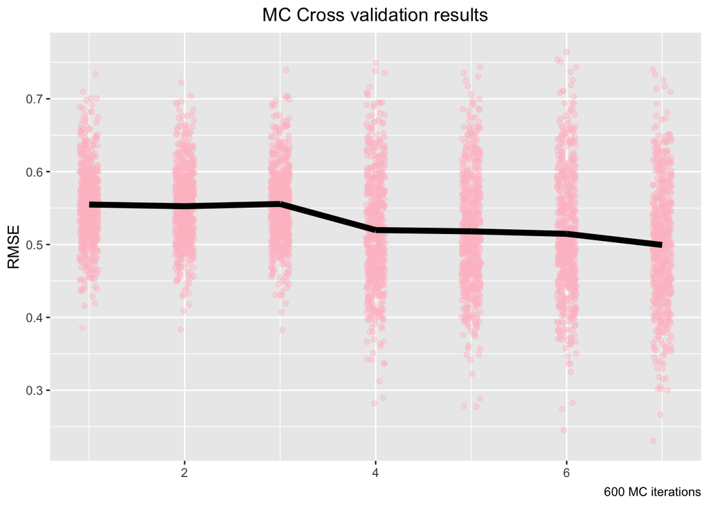

```
##
## Call:
## lm(formula = happiness_score ~ gdp_per_capita + health + freedom +
##     family + generosity + government_trust + cpi_score, data = WHC_Africa)
##
## Residuals:
##      Min       1Q   Median       3Q      Max
## -1.23701 -0.27779  0.02617  0.28009  1.37341
##
## Coefficients:
##                  Estimate Std. Error t value Pr(>|t|)
## (Intercept)       3.14119    0.27249  11.528  < 2e-16 ***
## gdp_per_capita    1.17246    0.23495   4.990 3.16e-06 ***
## health            1.28523    0.35221   3.649 0.000453 ***
## freedom           1.02147    0.54010   1.891 0.061996 .
## family            0.29955    0.20772   1.442 0.152962
## generosity        0.63987    0.73715   0.868 0.387821
## government_trust -0.51843    0.70394  -0.736 0.463470
## cpi_score        -0.17530    0.06249  -2.805 0.006228 **
## ---
## Signif. codes:  0 '***' 0.001 '**' 0.01 '*' 0.05 '.' 0.1 ' ' 1
##
## Residual standard error: 0.4766 on 85 degrees of freedom
##   (99 observations deleted due to missingness)
## Multiple R-squared:  0.586,  Adjusted R-squared:  0.5519
## F-statistic: 17.18 on 7 and 85 DF,  p-value: 5.69e-14
```

Our process of analyzing models for the data subsets mirrored the method used to analyze the model for the entire data set described above. We started by investigating the continent data subsets. The initial linear regression model came from a subset of our data set that only contains data for the continent of Africa. As with the previous initial model, the happiness score is the dependent variable, while the determinants of happiness and the CPI score are the independent variables. The model selection results display that the best combination of independent variables to influence the happiness score in Africa includes the same independent variables used in the initial model. Based on these results, we constructed a multiple linear regression model and used the outcomes of its model summary for analysis. The y-intercept of this model is 3.14119, and the independent variables with the largest coefficients were health, GDP per capita, and freedom– with health having the highest coefficient. Therefore, the independent variables that most influenced the happiness score in Africa were health, GDP per capita, and freedom. The adjusted R^2 value for this model is 0.5519, while the p-value of this model is 5.69e-14, with alpha set at 0.05 and degrees of freedom at 85. This p-value suggests that we can reject the null hypothesis explaining that the relationship between the variables is 0 because there is evidence of a statistically significant relationship between the variables in this model.

```
##
## Call:
## lm(formula = happiness_score ~ gdp_per_capita + health + freedom +
##     family + generosity + government_trust + cpi_score, data = WHC_Asia)
##
## Residuals:
##      Min       1Q   Median       3Q      Max
## -1.23998 -0.27709 -0.00759  0.27647  1.30798
##
## Coefficients:
##                  Estimate Std. Error t value Pr(>|t|)
## (Intercept)       2.39218    0.23900  10.009  < 2e-16 ***
## gdp_per_capita    1.09000    0.21127   5.159 1.24e-06 ***
## health            0.91249    0.49194   1.855 0.066529 .
## freedom           0.23903    0.47617   0.502 0.616764
## family            0.73540    0.19027   3.865 0.000197 ***
## generosity        0.73288    0.31178   2.351 0.020684 *
## government_trust  1.23967    0.53159   2.332 0.021685 *
## cpi_score         0.02834    0.05274   0.537 0.592249
## ---
## Signif. codes:  0 '***' 0.001 '**' 0.01 '*' 0.05 '.' 0.1 ' ' 1
##
## Residual standard error: 0.4733 on 101 degrees of freedom
## Multiple R-squared:  0.7215, Adjusted R-squared:  0.7022
## F-statistic: 37.37 on 7 and 101 DF,  p-value: < 2.2e-16
```

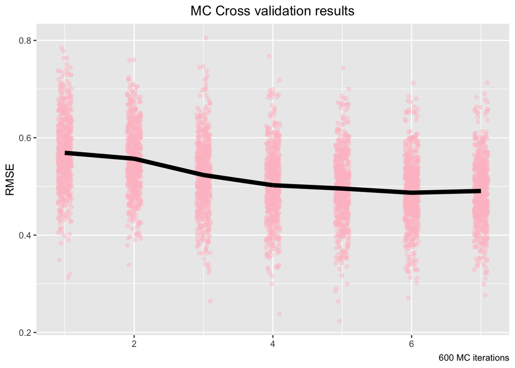

```
##
## Call:
## lm(formula = happiness_score ~ gdp_per_capita + health + family +
##     generosity + government_trust + cpi_score, data = WHC_Asia)
##
## Residuals:
##      Min       1Q   Median       3Q      Max
## -1.22228 -0.30421 -0.02687  0.28574  1.29542
##
## Coefficients:
##                  Estimate Std. Error t value Pr(>|t|)
## (Intercept)       2.41883    0.23217  10.418  < 2e-16 ***
## gdp_per_capita    1.05967    0.20170   5.254 8.20e-07 ***
## health            0.96542    0.47874   2.017  0.04637 *
## family            0.78488    0.16216   4.840 4.63e-06 ***
## generosity        0.77073    0.30141   2.557  0.01203 *
## government_trust  1.34125    0.48976   2.739  0.00728 **
## cpi_score         0.02805    0.05254   0.534  0.59458
## ---
## Signif. codes:  0 '***' 0.001 '**' 0.01 '*' 0.05 '.' 0.1 ' ' 1
##
## Residual standard error: 0.4716 on 102 degrees of freedom
## Multiple R-squared:  0.7208, Adjusted R-squared:  0.7043
## F-statistic: 43.88 on 6 and 102 DF,  p-value: < 2.2e-16
```

```
##
## Call:
## lm(formula = happiness_score ~ gdp_per_capita + health + freedom +
##     family + generosity + government_trust, data = WHC_NorthAmerica)
##
## Residuals:
##        1        2        3        4        5        6       13       14
## -0.03439  0.05553 -0.01627  0.02924  0.04284 -0.06515 -0.00800  0.02005
##       15
## -0.02385
##
## Coefficients:
##                  Estimate Std. Error t value Pr(>|t|)
## (Intercept)        4.3676     4.8875   0.894    0.466
## gdp_per_capita     1.1078     2.0681   0.536    0.646
## health            -0.8045     6.0655  -0.133    0.907
## freedom            8.0198     6.3063   1.272    0.331
## family            -1.1697     0.5530  -2.115    0.169
## generosity        -1.9847     2.7889  -0.712    0.550
## government_trust  -1.0028     2.8468  -0.352    0.758
##
## Residual standard error: 0.07906 on 2 degrees of freedom
##   (9 observations deleted due to missingness)
## Multiple R-squared:  0.9805, Adjusted R-squared:  0.9221
## F-statistic: 16.77 on 6 and 2 DF,  p-value: 0.05732
```

```
##
## Call:
## lm(formula = happiness_score ~ gdp_per_capita + health + freedom +
##     family + generosity + government_trust + cpi_score, data = WHC_Australia)
##
## Residuals:
## ALL 6 residuals are 0: no residual degrees of freedom!
##
## Coefficients: (2 not defined because of singularities)
##                  Estimate Std. Error t value Pr(>|t|)
## (Intercept)        8.7485        NaN     NaN      NaN
## gdp_per_capita    -0.1486        NaN     NaN      NaN
## health            -1.2239        NaN     NaN      NaN
## freedom            0.5676        NaN     NaN      NaN
## family            -0.1185        NaN     NaN      NaN
## generosity        -0.7821        NaN     NaN      NaN
## government_trust       NA         NA      NA       NA
## cpi_score              NA         NA      NA       NA
##
## Residual standard error: NaN on 0 degrees of freedom
##   (6 observations deleted due to missingness)
## Multiple R-squared:      1,  Adjusted R-squared:    NaN
## F-statistic:   NaN on 5 and 0 DF,  p-value: NA
```

```
##
## Call:
## lm(formula = happiness_score ~ gdp_per_capita + health + freedom +
##     family + generosity + government_trust + cpi_score, data = WHC_Europe)
##
## Residuals:
##      Min       1Q   Median       3Q      Max
## -1.00627 -0.25400  0.03021  0.24328  1.00754
##
## Coefficients:
##                  Estimate Std. Error t value Pr(>|t|)
## (Intercept)       3.37086    0.42976   7.844 4.68e-12 ***
## gdp_per_capita    0.68111    0.34312   1.985 0.049853 *
## health            0.01745    0.60330   0.029 0.976979
## freedom           1.00323    0.52220   1.921 0.057533 .
## family            0.26678    0.21025   1.269 0.207397
## generosity        1.03055    0.40217   2.562 0.011869 *
## government_trust  2.06510    0.58695   3.518 0.000652 ***
## cpi_score         0.09947    0.06136   1.621 0.108124
## ---
## Signif. codes:  0 '***' 0.001 '**' 0.01 '*' 0.05 '.' 0.1 ' ' 1
##
## Residual standard error: 0.4263 on 101 degrees of freedom
## Multiple R-squared:  0.8083, Adjusted R-squared:  0.795
## F-statistic: 60.82 on 7 and 101 DF,  p-value: < 2.2e-16
```

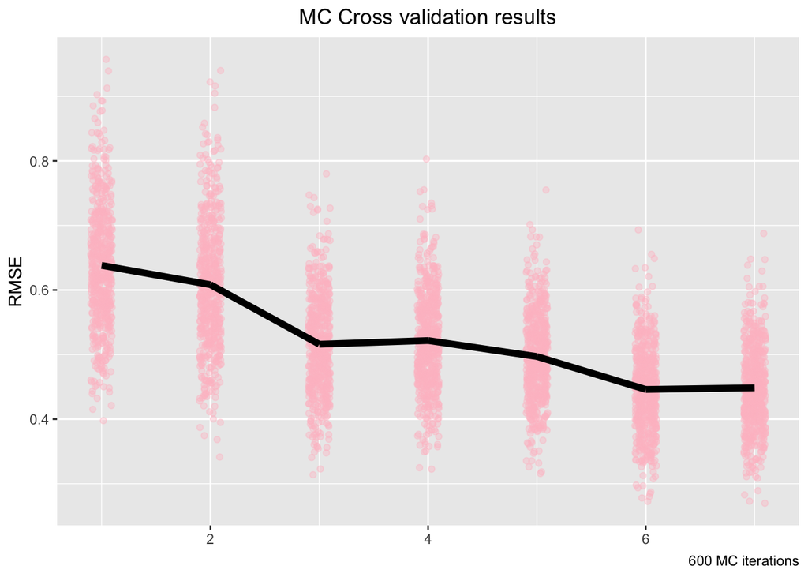

```
##
## Call:
## lm(formula = happiness_score ~ gdp_per_capita + health + freedom +
##     family + generosity + government_trust + cpi_score, data = WHC_Europe)
##
## Residuals:
##      Min       1Q   Median       3Q      Max
## -1.00627 -0.25400  0.03021  0.24328  1.00754
##
## Coefficients:
##                  Estimate Std. Error t value Pr(>|t|)
## (Intercept)       3.37086    0.42976   7.844 4.68e-12 ***
## gdp_per_capita    0.68111    0.34312   1.985 0.049853 *
## health            0.01745    0.60330   0.029 0.976979
## freedom           1.00323    0.52220   1.921 0.057533 .
## family            0.26678    0.21025   1.269 0.207397
## generosity        1.03055    0.40217   2.562 0.011869 *
## government_trust  2.06510    0.58695   3.518 0.000652 ***
## cpi_score         0.09947    0.06136   1.621 0.108124
## ---
## Signif. codes:  0 '***' 0.001 '**' 0.01 '*' 0.05 '.' 0.1 ' ' 1
##
## Residual standard error: 0.4263 on 101 degrees of freedom
## Multiple R-squared:  0.8083, Adjusted R-squared:  0.795
## F-statistic: 60.82 on 7 and 101 DF,  p-value: < 2.2e-16
```

The initial linear regression model came from a subset of our data set that only contains data for the continent of Europe. As with the previous initial model, the happiness score is the dependent variable, while the determinants of happiness and the CPI score are the independent variables. The model selection results display that the best combination of independent variables to influence the happiness score in Europe includes the same independent variables used in the initial model. Based on these results, we constructed a multiple linear regression model and used the outcomes of its model summary for analysis. The y-intercept of this model is 3.37086, and the independent variables with the largest coefficients were government trust, generosity, and freedom– with government trust having the highest coefficient. Therefore, the independent variables that most influenced the happiness score in Europe were government trust, generosity, and freedom. The adjusted R^2 value for this model is 0.795, while the p-value is < 2.2e-16, with alpha set at 0.05 and degrees of freedom at 101. This p-value suggests that we can reject the null hypothesis explaining that the relationship between the variables is 0 because there is evidence of a statistically significant relationship between the variables in this model.

```
##
## Call:
## lm(formula = happiness_score ~ gdp_per_capita + health + freedom +
##     family + generosity + government_trust + cpi_score, data = WHC_SouthAmerica)
##
## Residuals:
##      Min       1Q   Median       3Q      Max
## -1.33673 -0.28009 -0.02407  0.31509  0.80127
##
## Coefficients:
##                  Estimate Std. Error t value Pr(>|t|)
## (Intercept)       2.45263    0.43999   5.574 8.97e-07 ***
## gdp_per_capita    1.79779    0.48031   3.743 0.000456 ***
## health            2.35555    0.68609   3.433 0.001178 **
## freedom           1.80433    0.65240   2.766 0.007844 **
## family           -0.36356    0.35509  -1.024 0.310637
## generosity        0.19867    0.80806   0.246 0.806755
## government_trust  0.26371    1.41285   0.187 0.852662
## cpi_score        -0.03541    0.06179  -0.573 0.569014
## ---
## Signif. codes:  0 '***' 0.001 '**' 0.01 '*' 0.05 '.' 0.1 ' ' 1
##
## Residual standard error: 0.4543 on 52 degrees of freedom
##   (60 observations deleted due to missingness)
## Multiple R-squared:   0.78,  Adjusted R-squared:  0.7504
## F-statistic: 26.34 on 7 and 52 DF,  p-value: 5.363e-15
```

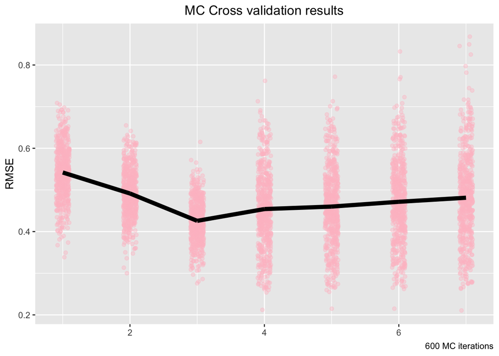

```
##
## Call:
## lm(formula = happiness_score ~ gdp_per_capita + health + freedom +
##     family, data = WHC_SouthAmerica)
##
## Residuals:
##      Min       1Q   Median       3Q      Max
## -1.29441 -0.26802  0.02395  0.30147  0.82834
##
## Coefficients:
##                Estimate Std. Error t value Pr(>|t|)
## (Intercept)      2.5440     0.2810   9.052 1.74e-12 ***
## gdp_per_capita   1.6609     0.3824   4.343 6.09e-05 ***
## health           2.3027     0.6400   3.598 0.000687 ***
## freedom          1.6919     0.5986   2.826 0.006555 **
## family          -0.3125     0.3256  -0.960 0.341420
## ---
## Signif. codes:  0 '***' 0.001 '**' 0.01 '*' 0.05 '.' 0.1 ' ' 1
##
## Residual standard error: 0.4432 on 55 degrees of freedom
##   (60 observations deleted due to missingness)
## Multiple R-squared:  0.7786, Adjusted R-squared:  0.7625
## F-statistic: 48.36 on 4 and 55 DF,  p-value: < 2.2e-16
```

```
##
## Call:
## lm(formula = happiness_score ~ gdp_per_capita + health + freedom,
##     data = WHC_NorthAmerica)
##
## Residuals:
##      Min       1Q   Median       3Q      Max
## -0.37642 -0.11454 -0.02561  0.06321  0.47834
##
## Coefficients:
##                Estimate Std. Error t value Pr(>|t|)
## (Intercept)      4.7516     0.5928   8.015 1.34e-06 ***
## gdp_per_capita   0.7290     0.3252   2.242   0.0417 *
## health           0.4923     0.8382   0.587   0.5663
## freedom          1.6857     0.9673   1.743   0.1033
## ---
## Signif. codes:  0 '***' 0.001 '**' 0.01 '*' 0.05 '.' 0.1 ' ' 1
##
## Residual standard error: 0.2177 on 14 degrees of freedom
## Multiple R-squared:  0.6126, Adjusted R-squared:  0.5296
## F-statistic: 7.381 on 3 and 14 DF,  p-value: 0.003341
```

```
##
## Call:
## lm(formula = happiness_score ~ gdp_per_capita + health + freedom,
##     data = WHC_Australia)
##
## Residuals:
##       Min        1Q    Median        3Q       Max
## -0.031915 -0.014035  0.002100  0.009825  0.038763
##
## Coefficients:
##                Estimate Std. Error t value Pr(>|t|)
## (Intercept)      8.3950     0.4609  18.215 8.48e-08 ***
## gdp_per_capita  -0.3463     0.1676  -2.067  0.07261 .
## health          -0.4421     0.1239  -3.569  0.00731 **
## freedom         -0.3792     0.2987  -1.270  0.23991
## ---
## Signif. codes:  0 '***' 0.001 '**' 0.01 '*' 0.05 '.' 0.1 ' ' 1
##
## Residual standard error: 0.02513 on 8 degrees of freedom
## Multiple R-squared:  0.6212, Adjusted R-squared:  0.4792
## F-statistic: 4.374 on 3 and 8 DF,  p-value: 0.04225
```

The initial linear regression model came from a subset of our data set that only contains data for the continent of Australia. As with the previous initial model, the happiness score is the dependent variable, while the determinants of happiness and the CPI score are the independent variables. The model selection results show that the best combination of influential independent variables for the happiness score in Australia includes GDP per capita, health, and freedom. Based on these results, we constructed a multiple linear regression model and used the outcomes of its model summary for analysis. The y-intercept of this model is 8.3950, and the independent variables with the largest coefficients were health, freedom, and GDP per capita– with health having the highest coefficient. Therefore, the independent variables that most influenced the happiness score in Australia were health, freedom, and GDP per capita. The adjusted R^2 value for this model is 0.4792, while the p-value is 0.04225, with alpha set at 0.05 and degrees of freedom at 8. This p-value suggests that we can reject the null hypothesis explaining that the relationship between the variables is 0 because there is evidence of a statistically significant relationship between the variables in this model.

Contrary to the results of our other models, this model summary for Australia shows a low adjusted R^2 value (suggesting that the independent variables do not lead to a significant amount of variance in the happiness score), a low-level degree of freedom, and a relatively high y-intercept and p-value. The model summary also shows a negative relationship between the happiness scores and all of the independent variables in the final model, which contradicts the positive relationship we observed between those variables during data exploration. We believe these results were caused by the minimal amount of observations in this data subset (Australia and New Zealand were the only countries part of this continent) and the high number of NA values in its variables.

## Predictions:

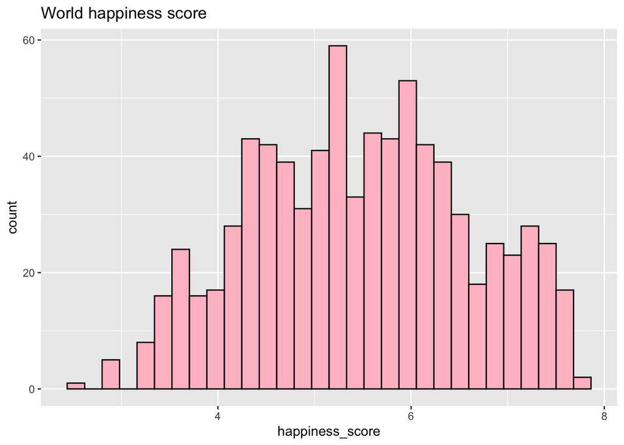

The histogram above conveys the distribution of happiness scores around the world over the 2015-2020 time period.

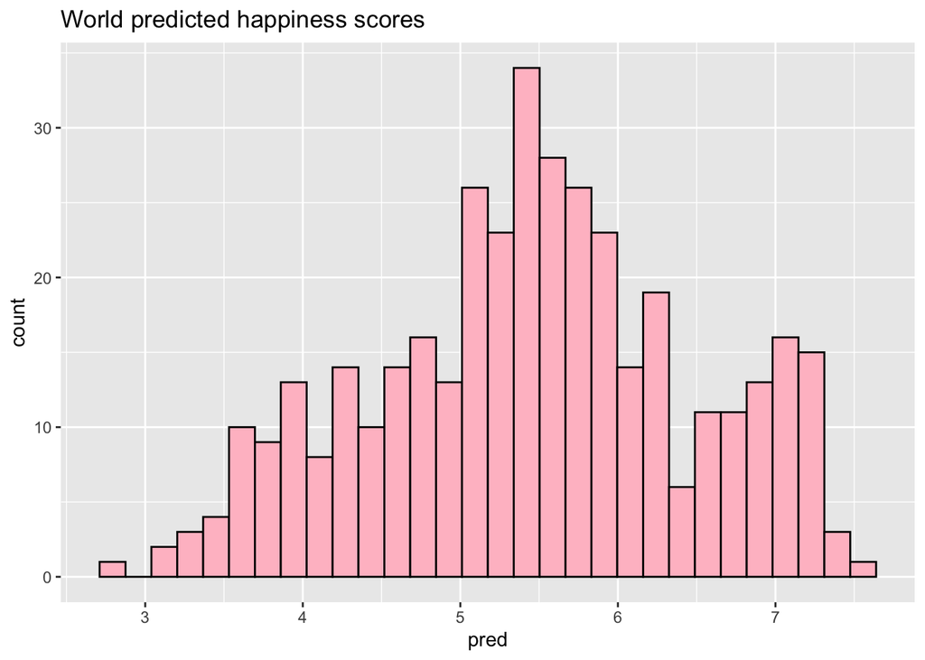

The histogram above conveys the distribution of predictions for happiness scores around the world based on the linear regression model, model1.

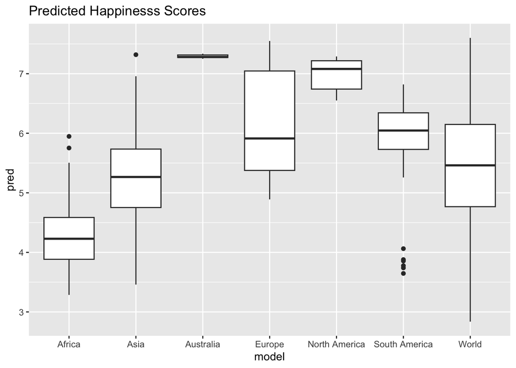

Above is a box plot comparing the distribution of predicted happiness scores for each continent as well as in general all around the globe. The way we set up these predictions is for each continent, we ran predictions based on the linear regression model that was selected through cross validation (shown previously). The predictions for worldwide happiness are run on the model1 linear regression model. Based on the visual above, we can see that the mean happiness score for Australia, Europe, North and South America are above the worldwide mean while the mean for the rest of the continents seems to fall below that threshold. Overall, the distribution for these predictions does not differ from the distribution of the actual recorded happiness scores (box plot shown in the Data Explanation and Exploration section). Based on our prediction, the ranking in means of predicted happiness scores across continents would be: Australia, North America, South America, Europe, Asia, and Africa (ranked descending).

# V. Conclusion:

Overall, Australia, Europe, and the Americas had the highest happiness scores above the other two continents in the data. We had anticipated that the pandemic would significantly change the happiness distribution and specific determinants of happiness, like health, but our data reveals the opposite. For many countries, health stayed the same, but “by far, the largest changes were in three types of benevolent actions, especially in 2021…In 2020, there was a substantial increase in help given to strangers but no substantial change in donations and volunteering. In 2021, all three types of activity were much higher than in 2017-2019, having an increase averaging about 25% of baseline activity” (Happiness, Benevolence, and Trust During COVID-19 and Beyond | the World Happiness Report, 2022).

Happiness, Benevolence, and Trust During COVID-19 and Beyond | The World Happiness Report. (2022, March 18). https://worldhappiness.report/ed/2022/happiness-benevolence-and-trust-during-covid-19-and-beyond/#ranking-of-happiness-2019-2021 Ngila, F. (2022, July 20). Covid made Africa the saddest continent. Quartz. https://qz.com/africa/2171425/world-happiness-report-africa-has-the-worlds-saddest-population